# Project 2 BUS 458H

Nash Lawrence & Kevin Wlosinski

9/18/2022

```r
library(tidyverse)
```

```r
library(dplyr)
library(ggplot2)
```

*2.) Read the data and provide Summary Statistics for both variables. Interpretations not needed*

```r
url <- "C:/Users/stewi/BUS 458H/Project_2.csv"
projectData <- read_csv(url)
head(projectData)
```

| ID | EngineSize | Cylinders | Horsepower | MPG_City | MPG_Highway | Weight | Wheelbase | Length | Make | Model | Type | Origin | DriveTrain | MSRP | Invoice |
| --- | --- | --- | --- | --- | --- | --- | --- | --- | --- | --- | --- | --- | --- | --- | --- |
| 1 | 3.5 | 6 | 265 | 17 | 23 | 4451 | 106 | 189 | Acura | MDX | SUV | Asia | All | 36945 | 33337 |
| 2 | 2.0 | 4 | 200 | 24 | 31 | 2778 | 101 | 172 | Acura | RSX Type S 2dr | Sedan | Asia | Front | 23820 | 21761 |
| 3 | 2.4 | 4 | 200 | 22 | 29 | 3230 | 105 | 183 | Acura | TSX 4dr | Sedan | Asia | Front | 26990 | 24647 |
| 4 | 3.2 | 6 | 270 | 20 | 28 | 3575 | 108 | 186 | Acura | TL 4dr | Sedan | Asia | Front | 33195 | 30299 |
| 5 | 3.5 | 6 | 225 | 18 | 24 | 3880 | 115 | 197 | Acura | 3.5 RL 4dr | Sedan | Asia | Front | 43755 | 39014 |
| 6 | 3.5 | 6 | 225 | 18 | 24 | 3893 | 115 | 197 | Acura | 3.5 RL w/Navigation 4dr | Sedan | Asia | Front | 46100 | 41100 |

```r
summary(projectData$MPG_City)
```

```
##    Min. 1st Qu.  Median    Mean 3rd Qu.    Max.
##   10.00   17.00   19.00   20.06   21.25   60.00
```

```r
summary(projectData$Horsepower)
```

```
##    Min. 1st Qu.  Median    Mean 3rd Qu.    Max.
##    73.0   165.0   210.0   215.9   255.0   500.0
```

*3.) Construct a scatter plot between MPG_City and Horsepower. Ensure that this plot is labeled correctly. Thoroughly interpret the plot. You may complete your write-up under the section headers.*

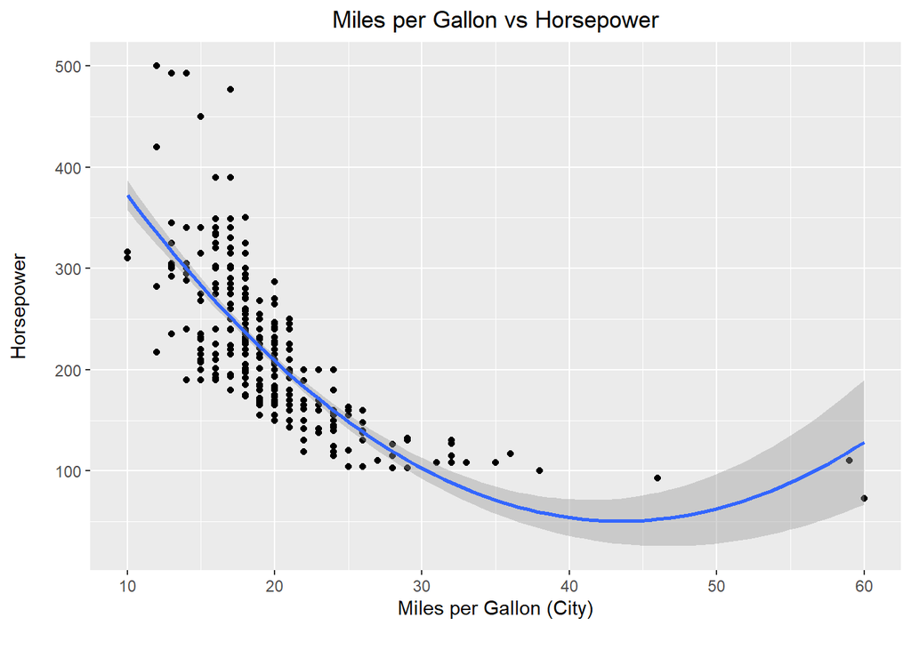

```r
scatPlot <- ggplot(data = projectData, aes(x = MPG_City, y = Horsepower))
scatPlot + labs(x = "Miles per Gallon (City)\n", y = "Horsepower\n", title = "Miles per Gallon vs Horsepower") + theme(plot.title = element_text(hjust = 0.5)) + scale_x_continuous(breaks = c(10,20,30,40,50,60)) + geom_point() + stat_smooth(method = lm, formula = y ~ x + I(x^2))
```

## Interpretations: The higher the Horsepower, the lower the MPG in the City. The graph seems to be exponential based on the pattern of the values on the graph. The two data points around 60 MPG look to be outliers, as all but 3 values are below 40 on the X-Axis. We counted 7 outliers for the MPG_City variable, and Zero for the Horsepower variable.

*Correlation between variables*

```r
cor(projectData$MPG_City, projectData$Horsepower)
```

```
## [1] -0.6766993
```

*Number of outliers for the MPG variable*

```r
Qone <- quantile(projectData$MPG_City, 0.25)
Qthree <- quantile(projectData$MPG_City, 0.75)
IQR <- Qthree - Qone
LOF <- Qone - 3.0 * IQR
UOF <- Qthree + 3.0 * IQR
numOutliesX <- projectData %>%
  filter(MPG_City < LOF | MPG_City > UOF)

count(numOutliesX)
```

| n |
| --- |
| 7 |

*Number of outliers for Horsepower variable*

```r
QoneY <- quantile(projectData$Horsepower, 0.25)
QthreeY <- quantile(projectData$Horsepower, 0.75)
IQRy <- QthreeY - QoneY
LOFy <- QoneY - 3.0 * IQRy
UOFy <- QthreeY + 3.0 * IQRy
numOutliesY <- projectData %>%
  filter(Horsepower < LOFy | Horsepower > UOFy)

count(numOutliesY)
```

| n |
| --- |
| 0 |

*4.) Conduct a simple linear regression between MPG_City and HP. Interpret the coefficient associated with Horsepower. Also interpret the R-Square value.*

```r
linReg <- lm(MPG_City ~ Horsepower, data = projectData)
linReg
```

```
##
## Call:
## lm(formula = MPG_City ~ Horsepower, data = projectData)
##
## Coefficients:
## (Intercept)   Horsepower
##    30.71347     -0.04934
```

## The coefficients suggest that Miles Per Gallon in the City is predicted by an intercpet of 30.71347, which decreases by an average of 0.04934 per Horsepower. The small standard error value suggests this is statistically significant.

```r
summary(linReg)
```

```
##
## Call:
## lm(formula = MPG_City ~ Horsepower, data = projectData)
##
## Residuals:
##    Min     1Q Median     3Q    Max
## -8.006 -2.114 -0.338  1.623 33.714
##
## Coefficients:
##              Estimate Std. Error t value Pr(>|t|)
## (Intercept) 30.713466   0.591757   51.90   <2e-16 ***
## Horsepower  -0.049344   0.002601  -18.97   <2e-16 ***
## ---
## Signif. codes:  0 '***' 0.001 '**' 0.01 '*' 0.05 '.' 0.1 ' ' 1
##
## Residual standard error: 3.861 on 426 degrees of freedom
## Multiple R-squared:  0.4579, Adjusted R-squared:  0.4566
## F-statistic: 359.9 on 1 and 426 DF,  p-value: < 2.2e-16
```

*Confidence intervals for the mean response*

```r
predict(linReg, data.frame(Horsepower=c(10,20,30,40,50,60)), interval = "confidence")
```

```
##        fit      lwr      upr
## 1 30.22002 29.10530 31.33475
## 2 29.72658 28.66000 30.79316
## 3 29.23314 28.21441 30.25186
## 4 28.73969 27.76849 29.71089
## 5 28.24625 27.32219 29.17031
## 6 27.75281 26.87544 28.63018
```

*Prediction intervals*

```r
predict(linReg, data.frame(Horsepower = c(10,20,30,40,50,60)), interval = "prediction")
```

```
##        fit      lwr      upr
## 1 30.22002 22.54920 37.89085
## 2 29.72658 22.06260 37.39056
## 3 29.23314 21.57567 36.89060
## 4 28.73969 21.08841 36.39098
## 5 28.24625 20.60081 35.89170
## 6 27.75281 20.11286 35.39275
```

*5.) Conduct a residual analysis for the model built in Step 4. Check with your instructor on the R code needed to accomplish this. Is the model you built in Step 4 appropriate? Why or Why not?*

```r
resAnalysis <- residuals(linReg)
head(resAnalysis)
```

```
##         1         2         3         4         5         6
## -0.637228  3.155393  1.155393  2.609493 -1.611000 -1.611000
```

*Residual Analysis of Original Linear Model*

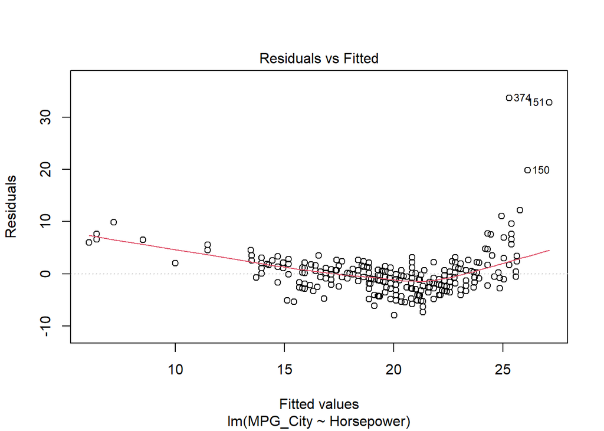

```r
plot(linReg, which = 1)
```

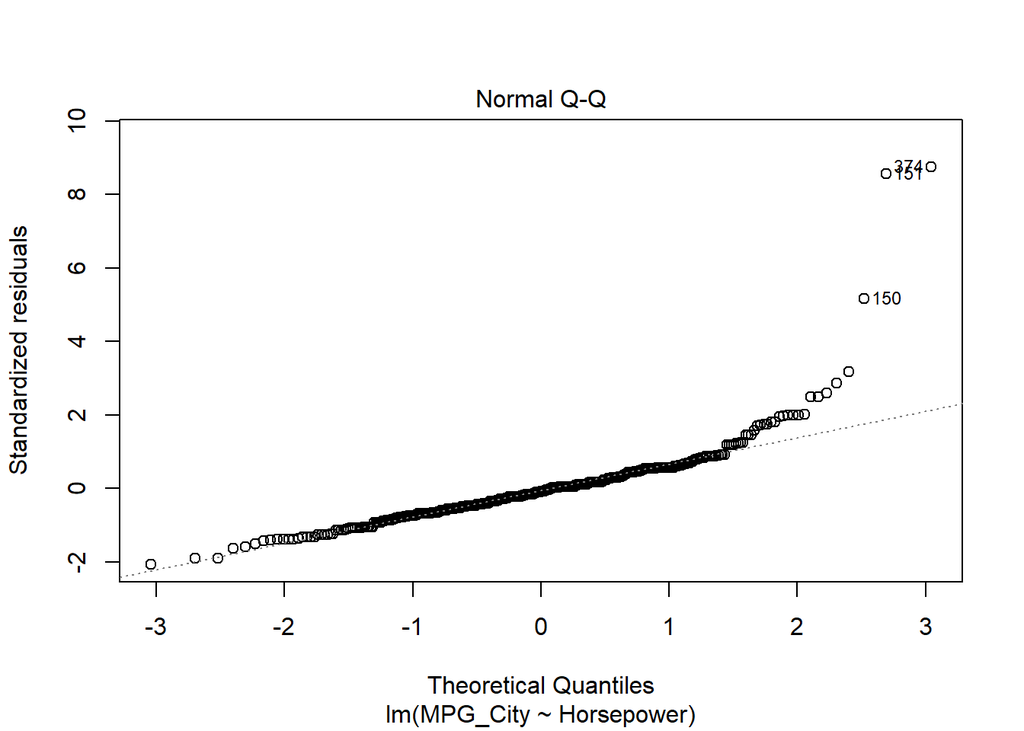

```r
plot(linReg, which = 2)
```

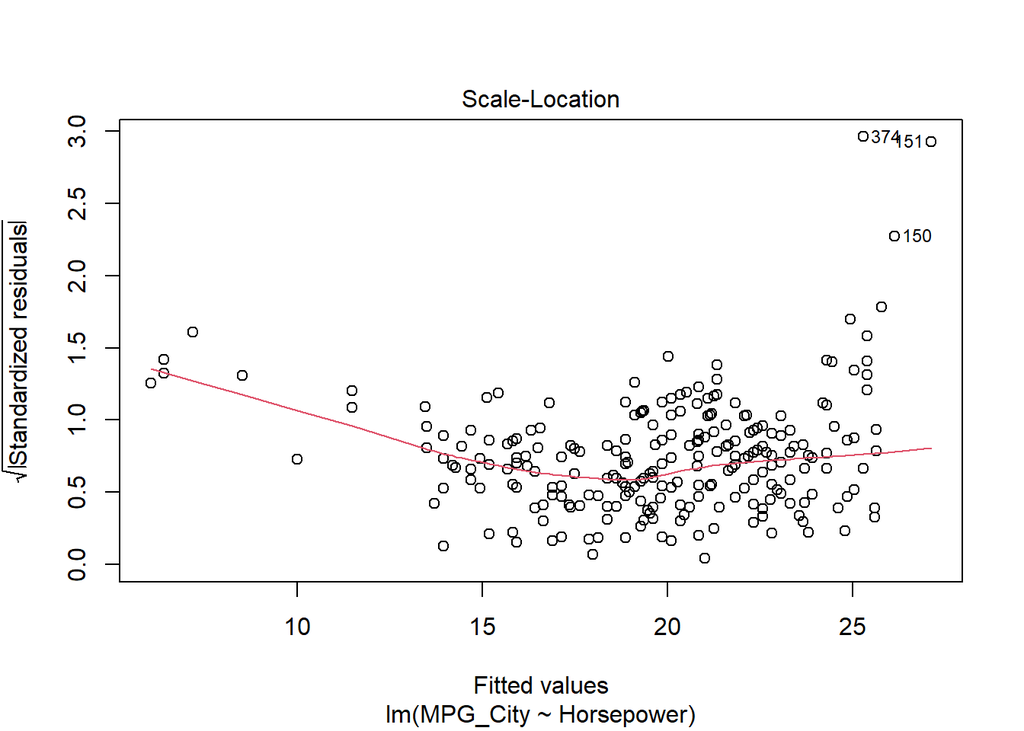

```r
plot(linReg, which = 3)
```

*Graph of the residual values and their distance from the least squares line*

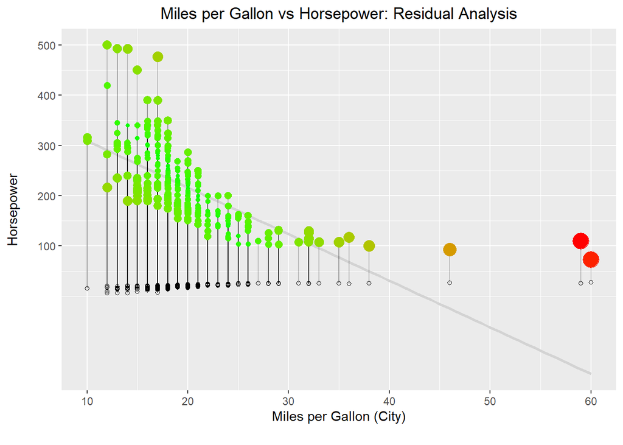

```r
projectData$predicted <- predict(linReg)
ggplot(data = projectData, aes(x = MPG_City, y = Horsepower)) + geom_smooth(method = "lm", se = FALSE, color = "lightgrey") + geom_segment(aes(xend = MPG_City, yend = predicted), alpha = .2) + geom_point(aes(color = abs(resAnalysis), size = abs(resAnalysis))) + scale_color_continuous(low = "green", high = "red") + guides(color = FALSE, size = FALSE) + geom_point(aes(y = predicted), shape = 1) + labs(x = "Miles per Gallon (City)\n", y = "Horsepower\n", title = "Miles per Gallon vs Horsepower: Residual Analysis") + theme(plot.title = element_text(hjust = 0.5)) + scale_x_continuous(breaks = c(10,20,30,40,50,60)) + scale_y_continuous(breaks = c(100,200,300,400,500))
```

*Statistical summary of the residual values*

```r
summary(resAnalysis)
```

```
##    Min. 1st Qu.  Median    Mean 3rd Qu.    Max.
## -8.0058 -2.1143 -0.3381  0.0000  1.6226 33.7144
```

*Find the Residual Sums of Squares (RSS)*

```r
squareResids <- round(resAnalysis ** 2, digits = 3)
RSS <- sum(squareResids)
RSS
```

```
## [1] 6351.199
```

*6.) Repeat Step 4 by log-transforming MPG_City. Interpret the coefficient associated with Horsepower.*

```r
projectData$mpgLog <- log(projectData$MPG_City)
head(projectData$mpgLog)
```

```
## [1] 2.833213 3.178054 3.091042 2.995732 2.890372 2.890372
```

```r
simpReg_logX <- lm(mpgLog ~ Horsepower, data = projectData)
simpReg_logX
```

```
##
## Call:
## lm(formula = mpgLog ~ Horsepower, data = projectData)
##
## Coefficients:
## (Intercept)   Horsepower
##    3.473175    -0.002324
```

```r
summary(simpReg_logX)
```

```
##
## Call:
## lm(formula = mpgLog ~ Horsepower, data = projectData)
##
## Residuals:
##      Min       1Q   Median       3Q      Max
## -0.48403 -0.08460  0.00117  0.08542  0.85997
##
## Coefficients:
##               Estimate Std. Error t value Pr(>|t|)
## (Intercept)  3.4731752  0.0232265  149.53   <2e-16 ***
## Horsepower  -0.0023237  0.0001021  -22.76   <2e-16 ***
## ---
## Signif. codes:  0 '***' 0.001 '**' 0.01 '*' 0.05 '.' 0.1 ' ' 1
##
## Residual standard error: 0.1516 on 426 degrees of freedom
## Multiple R-squared:  0.5487, Adjusted R-squared:  0.5477
## F-statistic:   518 on 1 and 426 DF,  p-value: < 2.2e-16
```

## Interpretations: After you log transform the MPG_City variable, the predicted value of MPG_City is calculated by an intercept of 3.4731752 which decreases by 0.0023237 per Horsepower

*7.) Repeat Step 4 by log-transforming MPG_City as well as Horsepower. Interpret the coefficient associated with Horsepower.*

```r
projectData$HorseLog <- log(projectData$Horsepower)
head(projectData$HorseLog)
```

```
## [1] 5.579730 5.298317 5.298317 5.598422 5.416100 5.416100
```

```r
bothLog_linReg <- lm(mpgLog ~ HorseLog, data = projectData)
bothLog_linReg
```

```
##
## Call:
## lm(formula = mpgLog ~ HorseLog, data = projectData)
##
## Coefficients:
## (Intercept)     HorseLog
##      5.9097      -0.5521
```

```r
summary(bothLog_linReg)
```

```
##
## Call:
## lm(formula = mpgLog ~ HorseLog, data = projectData)
##
## Residuals:
##      Min       1Q   Median       3Q      Max
## -0.45429 -0.08584  0.01149  0.07947  0.76320
##
## Coefficients:
##             Estimate Std. Error t value Pr(>|t|)
## (Intercept)   5.9097     0.1050   56.27   <2e-16 ***
## HorseLog     -0.5522     0.0197  -28.03   <2e-16 ***
## ---
## Signif. codes:  0 '***' 0.001 '**' 0.01 '*' 0.05 '.' 0.1 ' ' 1
##
## Residual standard error: 0.1338 on 426 degrees of freedom
## Multiple R-squared:  0.6484, Adjusted R-squared:  0.6476
## F-statistic: 785.7 on 1 and 426 DF,  p-value: < 2.2e-16
```

*8.) Conduct a thorough residual analysis for the model you built in Step 7. Is this model appropriate? Why or why not?*

## The model built in step 7 is appropriate because I log transformed both variables and conducted a linear regression model with the log transformed variables to interpret the coefficients

```r
analysis_residLog <- residuals(bothLog_linReg)
head(analysis_residLog)
```

```
##            1            2            3            4            5            6
##  0.004355035  0.193814161  0.106802784  0.177194791 -0.028834230 -0.028834230
```

```r
summary(analysis_residLog)
```

```
##     Min.  1st Qu.   Median     Mean  3rd Qu.     Max.
## -0.45429 -0.08584  0.01149  0.00000  0.07947  0.76320
```

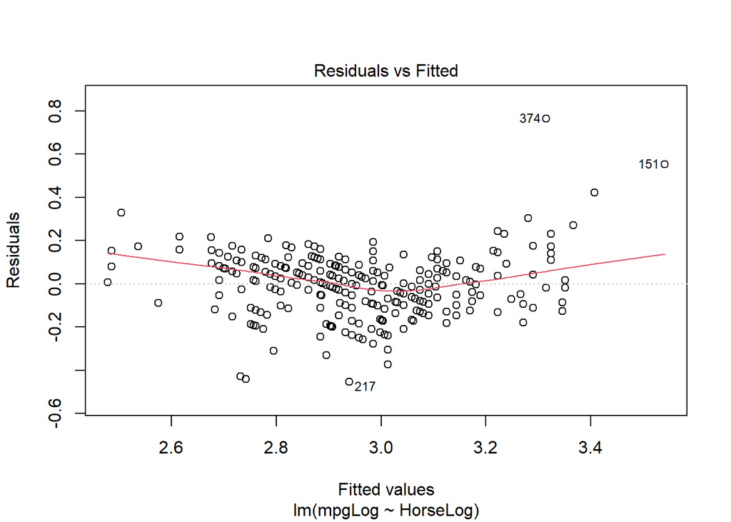

```r
plot(bothLog_linReg, which = 1)
```

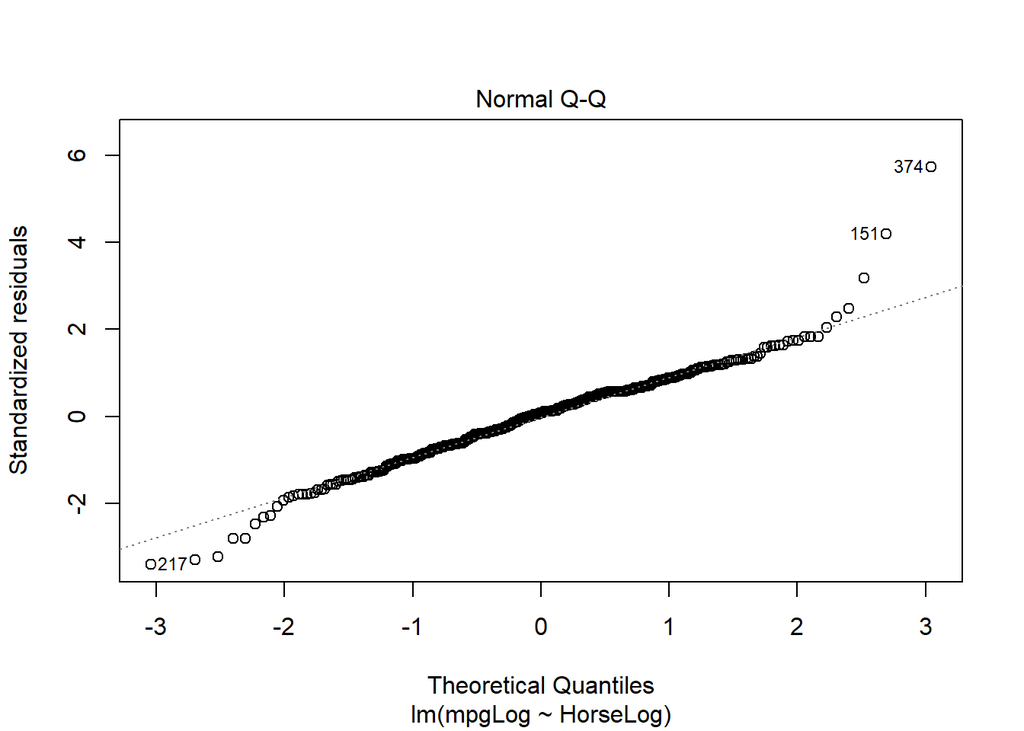

```r
plot(bothLog_linReg, which = 2)
```

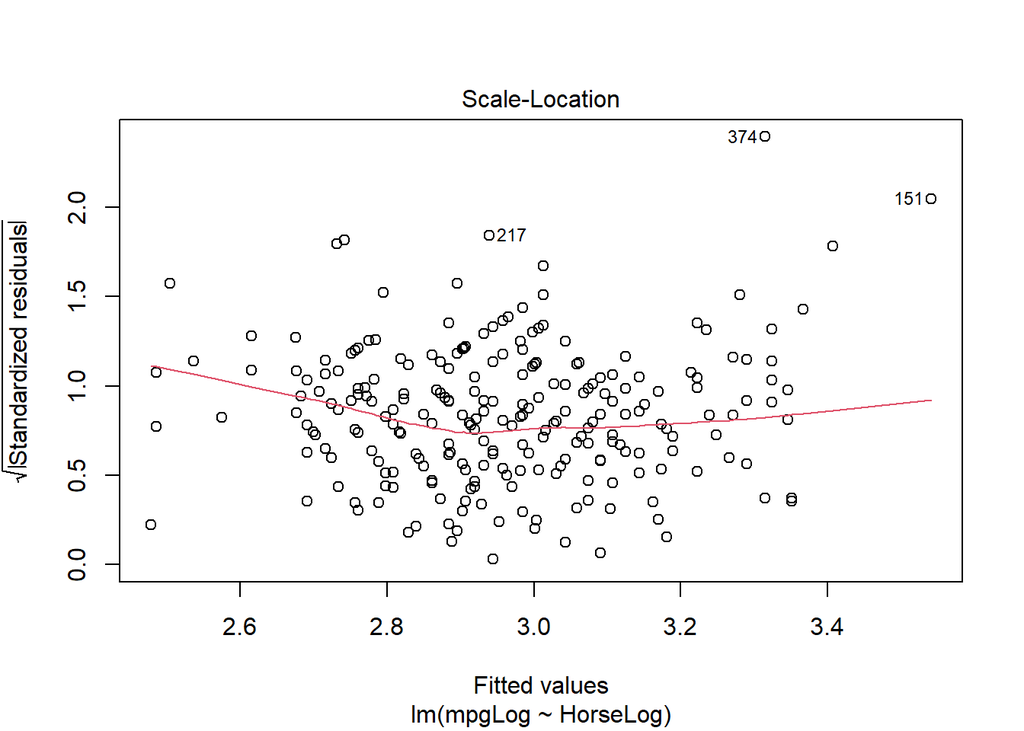

```r
plot(bothLog_linReg, which = 3)
```

*Get the Residual Sums of Squares (RSS)*

```r
squareLog_resids <- round(analysis_residLog ** 2, digits = 3)
RSS_log <- sum(squareLog_resids)
RSS_log
```

```
## [1] 7.63
```